# Recap Lab 7

Leon Eyrich Jessen

2026

## Functional Programming with `Purrr`

### No loop - Pure `func`!

## Aim

- Lab 2: Genomics, the `gravier` data from [A prognostic DNA signature for T1T2 node-negative breast cancer patients](https://pubmed.ncbi.nlm.nih.gov/20842727/)

*Today, we will re-examine the data acquired in Lab 2 to investigate the research question:*

- **What genes are significantly up-/down-regulated between the patients with- and without early metastasis?“**

## Load Data

```r
load(file = "data/_raw/gravier.RData")
```

## Inspect Data

```r
gravier |> names()
```

```
[1] "x" "y"
```

```r
gravier |> pluck("x") |> head()
```

```
         g2E09        g7F07        g1A01       g3C09        g3H08       g1A08
1 -0.001443417 -0.001443417 -0.083141235 -0.04752940  0.015782997 -0.03356953
2 -0.060397280  0.012926174 -0.001443417  0.01044266  0.031574283  0.10835718
3  0.039840265  0.052415894 -0.078563669  0.06350294 -0.039488290  0.03421572
4  0.010063683  0.031395196 -0.021804370  0.02147973  0.086783766  0.02715405
5  0.049630768  0.020057652  0.037030731  0.03113668  0.020657954 -0.01741705
6 -0.066427362  0.046840254  0.007195501 -0.36959453  0.002882509  0.02431968
         g1B01      g1int1        g1E11        g8G02        g1H04        g1C01
1 -0.136061550  0.01798128  0.025737561  0.007195501 -0.013043037 -0.267079618
2  0.015782997  0.07997538 -0.005782353  0.000000000  0.096261853  0.199122642
3  0.002882509  0.05935528  0.032806145  0.021479727  0.066261442 -0.051399153
4 -0.015957574  0.07587487  0.015782997 -0.104697379  0.029982866  0.005759269
5  0.111031312 -0.04692105  0.052415894  0.052415894  0.051024003  0.109694865
6  0.090853430  0.04823619  0.032806145  0.142740172  0.007195501  0.015782997
         g1F11       g3F05        g3B09       g1int2      g2C01        g1A05
```

[output cut: 3345 more lines]

```r
gravier |> pluck("y") |> head()
```

```
[1] good good good good good good
Levels: good poor
```

## Clean Data

```r
gravier_clean <- gravier |>
  bind_cols() |>
  as_tibble()
gravier_clean
```

```
# A tibble: 168 × 2,906
      g2E09    g7F07    g1A01   g3C09      g3H08    g1A08    g1B01   g1int1
      <dbl>    <dbl>    <dbl>   <dbl>      <dbl>    <dbl>    <dbl>    <dbl>
 1 -0.00144 -0.00144 -0.0831  -0.0475  0.0158    -0.0336  -0.136    0.0180
 2 -0.0604   0.0129  -0.00144  0.0104  0.0316     0.108    0.0158   0.0800
 3  0.0398   0.0524  -0.0786   0.0635 -0.0395     0.0342   0.00288  0.0594
 4  0.0101   0.0314  -0.0218   0.0215  0.0868     0.0272  -0.0160   0.0759
 5  0.0496   0.0201   0.0370   0.0311  0.0207    -0.0174   0.111   -0.0469
 6 -0.0664   0.0468   0.00720 -0.370   0.00288    0.0243   0.0909   0.0482
 7 -0.00289 -0.0816  -0.0291  -0.0249 -0.0174     0.0172  -0.170   -0.00578
 8 -0.198   -0.0499  -0.0634  -0.0298  0.0300     0.00144 -0.0529  -0.0401
 9  0.00288  0.0201   0.0272   0.0174 -0.0000789 -0.0634   0.0370   0.0314
10 -0.0574  -0.0574  -0.0831  -0.0897 -0.101     -0.144   -0.167    0.0172
# ℹ 158 more rows
# ℹ 2,898 more variables: g1E11 <dbl>, g8G02 <dbl>, g1H04 <dbl>, g1C01 <dbl>,
#   g1F11 <dbl>, g3F05 <dbl>, g3B09 <dbl>, g1int2 <dbl>, g2C01 <dbl>,
#   g1A05 <dbl>, g1E01 <dbl>, g1B05 <dbl>, g3C05 <dbl>, g3A07 <dbl>,
#   g1F01 <dbl>, g2D01 <dbl>, g1int3 <dbl>, g1int4 <dbl>, g1D05 <dbl>,
#   g1E05 <dbl>, g1G05 <dbl>, g1C05 <dbl>, g1G11 <dbl>, g2D08 <dbl>,
#   g2E06 <dbl>, g3H09 <dbl>, g2F09 <dbl>, g3G06 <dbl>, g2G08 <dbl>, …
```

- **Q3: Discuss in your group if this is tidy data?**
- **Q4: In fact, specifically state what are the “rules” for tidy data?**
- **Q5: In your group, discuss why `bind_cols` can by *very very* dangerous to use?**

## Write the clean data to disk

- **T3: In your “Clean Data”-section, add a new chunk, where you write a tab-separated-values gzipped (i.e. compressed) file called “02_gravier_clean” (with the correct filetype specification) into your “data”-folder**

```r
gravier_clean  |>
  write_tsv(file = "data/02_gravier_clean.tsv.gz")
```

## Augment Data

- **T4: Create a new “Augment Data” header in your document and add the below chunk:**

```r
gravier_clean_aug <- gravier_clean |>
  mutate(y = case_when(y == "poor" ~ 1,
                       y == "good" ~ 0)) |>
  relocate(early_metastasis = y)
```

## Augment Data

- **T4: Create a new “Augment Data” header in your document and add the below chunk:**

```r
gravier_clean_aug <- gravier_clean |>
  mutate(y = case_when(y == "poor" ~ 1,
                       y == "good" ~ 0)) |>
  relocate(y) |>
  rename(early_metastasis = y)
```

## Write the augmented data to disk

- **T5: In your “Augment Data”-section, add a new chunk, where you write a tab-separated-values gzipped (i.e. compressed) file called “03_gravier_clean_aug” (with the correct filetype specification) into your “data”-folder**

```r
gravier_clean_aug  |>
  write_tsv(file = "data/03_gravier_clean_aug.tsv.gz")
```

## Analysis

### One Gene, one model - Let’s fit our first model!

- **T7: Use the `lm()` function to create your first model and save it to a new variable e.g. “my_first_model”**

```r
my_first_model <- gravier_clean_aug |>
  lm(formula = g2E09 ~ early_metastasis,
     data = _)
```

- **Q7: What are your coefficients? Mine are:**

```r
my_first_model |>
  pluck("coefficients")
```

```
     (Intercept) early_metastasis
     -0.01616011      -0.03426164
```

## Analysis

- **T8: Use the `group_by()` $\rightarrow$ `summarise()` workflow to calculate the mean values of the gene expression for your favourite gene stratified on `early_metastasis`**
- **Q8: What are your mean values? Mine are:**

```r
gravier_clean_aug |>
  group_by(early_metastasis) |>
  summarise(mu = mean(g2E09))
```

```
# A tibble: 2 × 2
  early_metastasis      mu
             <dbl>   <dbl>
1                0 -0.0162
2                1 -0.0504
```

## Analysis

- **Q9: Discuss in your group: How are your coefficients related to your mean expression values?**

```r
my_first_model |>
  summary()
```

```
Call:
lm(formula = g2E09 ~ early_metastasis, data = gravier_clean_aug)

Residuals:
     Min       1Q   Median       3Q      Max
-0.48282 -0.05133  0.02694  0.07031  0.25206

Coefficients:
                 Estimate Std. Error t value Pr(>|t|)
(Intercept)      -0.01616    0.01170  -1.381   0.1690
early_metastasis -0.03426    0.02008  -1.706   0.0899 .
---
Signif. codes:  0 '***' 0.001 '**' 0.01 '*' 0.05 '.' 0.1 ' ' 1

Residual standard error: 0.1232 on 166 degrees of freedom
Multiple R-squared:  0.01723,   Adjusted R-squared:  0.01131
F-statistic:  2.91 on 1 and 166 DF,  p-value: 0.08988
```

```r
gravier_clean_aug |>
  group_by(early_metastasis) |>
  summarise(mu = mean(g2E09))
```

```
# A tibble: 2 × 2
  early_metastasis      mu
             <dbl>   <dbl>
1                0 -0.0162
2                1 -0.0504
```

- **Q10: Discuss in your group: Is your gene up- or down-regulated from `early_metastasis = 0` to `early_metastasis = 1` and use the `summary()` function to see if is it statistically significant at a level of significance of $\alpha = 0.05$?**

## All the Genes, all the models

- **Q11: How many genes are there in the `gravier` data set?**

```r
gravier_clean_aug
```

```
# A tibble: 168 × 2,906
   early_metastasis    g2E09    g7F07    g1A01   g3C09      g3H08    g1A08
              <dbl>    <dbl>    <dbl>    <dbl>   <dbl>      <dbl>    <dbl>
 1                0 -0.00144 -0.00144 -0.0831  -0.0475  0.0158    -0.0336
 2                0 -0.0604   0.0129  -0.00144  0.0104  0.0316     0.108
 3                0  0.0398   0.0524  -0.0786   0.0635 -0.0395     0.0342
 4                0  0.0101   0.0314  -0.0218   0.0215  0.0868     0.0272
 5                0  0.0496   0.0201   0.0370   0.0311  0.0207    -0.0174
 6                0 -0.0664   0.0468   0.00720 -0.370   0.00288    0.0243
 7                0 -0.00289 -0.0816  -0.0291  -0.0249 -0.0174     0.0172
 8                0 -0.198   -0.0499  -0.0634  -0.0298  0.0300     0.00144
 9                0  0.00288  0.0201   0.0272   0.0174 -0.0000789 -0.0634
10                0 -0.0574  -0.0574  -0.0831  -0.0897 -0.101     -0.144
# ℹ 158 more rows
# ℹ 2,899 more variables: g1B01 <dbl>, g1int1 <dbl>, g1E11 <dbl>, g8G02 <dbl>,
#   g1H04 <dbl>, g1C01 <dbl>, g1F11 <dbl>, g3F05 <dbl>, g3B09 <dbl>,
#   g1int2 <dbl>, g2C01 <dbl>, g1A05 <dbl>, g1E01 <dbl>, g1B05 <dbl>,
#   g3C05 <dbl>, g3A07 <dbl>, g1F01 <dbl>, g2D01 <dbl>, g1int3 <dbl>,
#   g1int4 <dbl>, g1D05 <dbl>, g1E05 <dbl>, g1G05 <dbl>, g1C05 <dbl>,
#   g1G11 <dbl>, g2D08 <dbl>, g2E06 <dbl>, g3H09 <dbl>, g2F09 <dbl>, …
```

- Now, we just have to make one model for each gene!
- In principle, you could overflow your environment with individual model objects
- Honestly, **let’s not!** Also, recall: *“We don’t loop, we func!”*, so let’s see how that would work.

## Models, models everywhere… Data Preparation…

- **Q12: Discuss in your group, if the `gravier_clean_aug` is a “wide” or a “long” dataset?**
- **T9: Create this long version of your `gravier_clean_aug` data and save it in `gravier_clean_aug_long`**

```r
gravier_clean_aug_long <- gravier_clean_aug |>
  pivot_longer(cols = starts_with("g"),
               names_to = "gene",
               values_to = "log2_expr_level")
gravier_clean_aug_long
```

```
# A tibble: 488,040 × 3
   early_metastasis gene   log2_expr_level
              <dbl> <chr>            <dbl>
 1                0 g2E09         -0.00144
 2                0 g7F07         -0.00144
 3                0 g1A01         -0.0831
 4                0 g3C09         -0.0475
 5                0 g3H08          0.0158
 6                0 g1A08         -0.0336
 7                0 g1B01         -0.136
 8                0 g1int1         0.0180
 9                0 g1E11          0.0257
10                0 g8G02          0.00720
# ℹ 488,030 more rows
```

## Models, models everywhere… Data Preparation…

- **T10: Create a `dplyr` pipeline, use the `group_by()` function to group your `gravier_clean_aug_long` dataset by `gene` and then add the `nest()` and `ungroup()` functions to your pipeline**

```r
gravier_clean_aug_long_nested <- gravier_clean_aug_long |>
  group_by(gene) |>
  nest() |>
  ungroup()
gravier_clean_aug_long_nested
```

```
# A tibble: 2,905 × 2
   gene   data
   <chr>  <list>
 1 g2E09  <tibble [168 × 2]>
 2 g7F07  <tibble [168 × 2]>
 3 g1A01  <tibble [168 × 2]>
 4 g3C09  <tibble [168 × 2]>
 5 g3H08  <tibble [168 × 2]>
 6 g1A08  <tibble [168 × 2]>
 7 g1B01  <tibble [168 × 2]>
 8 g1int1 <tibble [168 × 2]>
 9 g1E11  <tibble [168 × 2]>
10 g8G02  <tibble [168 × 2]>
# ℹ 2,895 more rows
```

```r
gravier_clean_aug_long_nested |>
  filter(gene == "g2E09") |>
  pull(data)
```

```
[[1]]
# A tibble: 168 × 2
   early_metastasis log2_expr_level
              <dbl>           <dbl>
 1                0        -0.00144
 2                0        -0.0604
 3                0         0.0398
 4                0         0.0101
 5                0         0.0496
 6                0        -0.0664
 7                0        -0.00289
 8                0        -0.198
 9                0         0.00288
10                0        -0.0574
# ℹ 158 more rows
```

## Fitting Models

- **T11: Use the `group_by()` function to let `R` know, that we want to work *per* gene**
- **T12: Then add a new line to your pipeline, where you add a new variable `model_object` to your `gravier_clean_aug_long_nested` dataset, which `R` will compute *per* gene**

```r
gravier_clean_aug_long_nested <- gravier_clean_aug_long_nested |>
  group_by(gene) |>
  mutate(model_object = map(.x = data,
                   .f = ~lm(formula = log2_expr_level ~ early_metastasis,
                            data = .x)))
gravier_clean_aug_long_nested
```

```
# A tibble: 2,905 × 3
# Groups:   gene [2,905]
   gene   data               model_object
   <chr>  <list>             <list>
 1 g2E09  <tibble [168 × 2]> <lm>
 2 g7F07  <tibble [168 × 2]> <lm>
 3 g1A01  <tibble [168 × 2]> <lm>
 4 g3C09  <tibble [168 × 2]> <lm>
 5 g3H08  <tibble [168 × 2]> <lm>
 6 g1A08  <tibble [168 × 2]> <lm>
 7 g1B01  <tibble [168 × 2]> <lm>
 8 g1int1 <tibble [168 × 2]> <lm>
 9 g1E11  <tibble [168 × 2]> <lm>
10 g8G02  <tibble [168 × 2]> <lm>
# ℹ 2,895 more rows
```

```r
gravier_clean_aug_long_nested |>
  filter(gene == "g2E09") |>
  pull(model_object)
```

```
[[1]]

Call:
lm(formula = log2_expr_level ~ early_metastasis, data = .x)

Coefficients:
     (Intercept)  early_metastasis
        -0.01616          -0.03426
```

## First use of the `map()` function

```r
model_object = map(.x = data,
                   .f = ~lm(formula = log2_expr_level ~ early_metastasis,
                            data = .x))
```

- `model_object` is a `new` variable, we are creating
- `.x` to what `existing` (nested) variable are we mapping?
- `.f` which function do we want to map to each element in the `existing` (nested) variable?
- *NB! The `log2_expr_level` and `early_metastasis` are variables “inside” the nested `data` variable*

## Tidying Models with the `broom` package

```r
my_first_model
```

```
Call:
lm(formula = g2E09 ~ early_metastasis, data = gravier_clean_aug)

Coefficients:
     (Intercept)  early_metastasis
        -0.01616          -0.03426
```

```r
tidy(x = my_first_model)
```

```
# A tibble: 2 × 5
  term             estimate std.error statistic p.value
  <chr>               <dbl>     <dbl>     <dbl>   <dbl>
1 (Intercept)       -0.0162    0.0117     -1.38  0.169
2 early_metastasis  -0.0343    0.0201     -1.71  0.0899
```

```r
tidy(x = my_first_model,
     conf.int = TRUE,
     conf.level = 0.95)
```

```
# A tibble: 2 × 7
  term             estimate std.error statistic p.value conf.low conf.high
  <chr>               <dbl>     <dbl>     <dbl>   <dbl>    <dbl>     <dbl>
1 (Intercept)       -0.0162    0.0117     -1.38  0.169   -0.0393   0.00694
2 early_metastasis  -0.0343    0.0201     -1.71  0.0899  -0.0739   0.00539
```

## Now, we want to apply this `tidy()` function *per `model_object`*

- **T13: Scroll a bit back to where we created the `model_object` and see if you can translate that into mapping the `tidy()` function to the `model_object` variable**

```r
gravier_clean_aug_long_nested <- gravier_clean_aug_long_nested |>
  mutate(model_object_tidy = map(.x = model_object,
                                 .f = ~tidy(x = .x,
                                            conf.int = TRUE,
                                            conf.level = 0.95)))
gravier_clean_aug_long_nested
```

```
# A tibble: 2,905 × 4
# Groups:   gene [2,905]
   gene   data               model_object model_object_tidy
   <chr>  <list>             <list>       <list>
 1 g2E09  <tibble [168 × 2]> <lm>         <tibble [2 × 7]>
 2 g7F07  <tibble [168 × 2]> <lm>         <tibble [2 × 7]>
 3 g1A01  <tibble [168 × 2]> <lm>         <tibble [2 × 7]>
 4 g3C09  <tibble [168 × 2]> <lm>         <tibble [2 × 7]>
 5 g3H08  <tibble [168 × 2]> <lm>         <tibble [2 × 7]>
 6 g1A08  <tibble [168 × 2]> <lm>         <tibble [2 × 7]>
 7 g1B01  <tibble [168 × 2]> <lm>         <tibble [2 × 7]>
 8 g1int1 <tibble [168 × 2]> <lm>         <tibble [2 × 7]>
 9 g1E11  <tibble [168 × 2]> <lm>         <tibble [2 × 7]>
10 g8G02  <tibble [168 × 2]> <lm>         <tibble [2 × 7]>
# ℹ 2,895 more rows
```

```r
gravier_clean_aug_long_nested |>
  filter(gene == "g2E09") |>
  pull(model_object_tidy)
```

```
[[1]]
# A tibble: 2 × 7
  term             estimate std.error statistic p.value conf.low conf.high
  <chr>               <dbl>     <dbl>     <dbl>   <dbl>    <dbl>     <dbl>
1 (Intercept)       -0.0162    0.0117     -1.38  0.169   -0.0393   0.00694
2 early_metastasis  -0.0343    0.0201     -1.71  0.0899  -0.0739   0.00539
```

## We’re almost there - Just a bit of wrangling to go!

- **T14: Create a `dplyr` pipeline and save the result in a new variable called `gravier_estimates`: Use the `unnest()` function to unpack the `model_object_tidy`**

```r
gravier_estimates <- gravier_clean_aug_long_nested |>
  unnest(model_object_tidy)
gravier_estimates
```

```
# A tibble: 5,810 × 10
# Groups:   gene [2,905]
   gene  data     model_object term         estimate std.error statistic p.value
   <chr> <list>   <list>       <chr>           <dbl>     <dbl>     <dbl>   <dbl>
 1 g2E09 <tibble> <lm>         (Intercept)  -0.0162     0.0117    -1.38  1.69e-1
 2 g2E09 <tibble> <lm>         early_metas… -0.0343     0.0201    -1.71  8.99e-2
 3 g7F07 <tibble> <lm>         (Intercept)   0.0604     0.0139     4.35  2.36e-5
 4 g7F07 <tibble> <lm>         early_metas… -0.0185     0.0238    -0.778 4.38e-1
 5 g1A01 <tibble> <lm>         (Intercept)  -0.0290     0.0123    -2.35  1.99e-2
 6 g1A01 <tibble> <lm>         early_metas… -0.0367     0.0211    -1.73  8.47e-2
 7 g3C09 <tibble> <lm>         (Intercept)   0.0518     0.0145     3.58  4.55e-4
 8 g3C09 <tibble> <lm>         early_metas… -0.0148     0.0249    -0.595 5.53e-1
 9 g3H08 <tibble> <lm>         (Intercept)   0.0142     0.0128     1.11  2.69e-1
10 g3H08 <tibble> <lm>         early_metas…  0.00247    0.0220     0.112 9.11e-1
# ℹ 5,800 more rows
# ℹ 2 more variables: conf.low <dbl>, conf.high <dbl>
```

## We’re almost there - Just a bit more of wrangling to go!

- **T15: The again, create a `dplyr` pipeline and save the result in a the same `gravier_estimates` variable: Subset the rows to only get the slope term and then choose variables as displayed below, finally end with un-grouping your data, as we no longer need the groups**

```r
gravier_estimates <- gravier_estimates |>
  filter(term == "early_metastasis") |>
  select(gene, p.value, estimate, conf.low, conf.high) |>
  ungroup()
gravier_estimates
```

```
# A tibble: 2,905 × 5
   gene   p.value estimate conf.low conf.high
   <chr>    <dbl>    <dbl>    <dbl>     <dbl>
 1 g2E09   0.0899 -0.0343   -0.0739   0.00539
 2 g7F07   0.438  -0.0185   -0.0655   0.0285
 3 g1A01   0.0847 -0.0367   -0.0784   0.00508
 4 g3C09   0.553  -0.0148   -0.0639   0.0343
 5 g3H08   0.911   0.00247  -0.0410   0.0459
 6 g1A08   0.859  -0.00363  -0.0438   0.0366
 7 g1B01   0.279  -0.0218   -0.0615   0.0178
 8 g1int1  0.666  -0.0113   -0.0627   0.0402
 9 g1E11   0.106  -0.0329   -0.0728   0.00703
10 g8G02   0.633  -0.0108   -0.0555   0.0338
# ℹ 2,895 more rows
```

## We’re almost there - Just a tiny bit more of wrangling to go!

- **T16: To your `gravier_estimates` dataset, add a variable `q.value`, which is the result of calling the `p.adjust()` function on your `p.value` variable and also add an indicator variable denoting if a given gene is significant or not**

```r
gravier_estimates <- gravier_estimates |>
  mutate(q.value = p.adjust(p.value),
         is_significant = case_when(q.value <= 0.05 ~ "yes",
                                    q.value > 0.05 ~ "no"))
gravier_estimates
```

```
# A tibble: 2,905 × 7
   gene   p.value estimate conf.low conf.high q.value is_significant
   <chr>    <dbl>    <dbl>    <dbl>     <dbl>   <dbl> <chr>
 1 g2E09   0.0899 -0.0343   -0.0739   0.00539       1 no
 2 g7F07   0.438  -0.0185   -0.0655   0.0285        1 no
 3 g1A01   0.0847 -0.0367   -0.0784   0.00508       1 no
 4 g3C09   0.553  -0.0148   -0.0639   0.0343        1 no
 5 g3H08   0.911   0.00247  -0.0410   0.0459        1 no
 6 g1A08   0.859  -0.00363  -0.0438   0.0366        1 no
 7 g1B01   0.279  -0.0218   -0.0615   0.0178        1 no
 8 g1int1  0.666  -0.0113   -0.0627   0.0402        1 no
 9 g1E11   0.106  -0.0329   -0.0728   0.00703       1 no
10 g8G02   0.633  -0.0108   -0.0555   0.0338        1 no
# ℹ 2,895 more rows
```

## Recap - What happened?

1. We have the `gravier` dataset, with the log2-expression levels for 2,905 genes of 168 patients of whom 111 did *not* have early metastasis and 57 who did
2. We are interested in investigating what genes are significantly up-/down-regulated between the patients with- and without early metastasis
3. First, we retrieved the data from the data repository, cleaned and augmented it and saved it to disk
4. Then pivoted the data, so we could work *per gene* (The `gene` variable)
5. Next, we grouped *per gene* and nested the data (The `data` variable)
6. Then, we fitted a linear model to each gene (The `model_object` variable)
7. Next, we used the `broom` package to tidy the fitted model incl. getting confidence intervals (The `model_object_tidy` variable)
8. Lastly, we extracted the model parameters, corrected for multiple testing and added and indicator for significant findings

## Awesome!

Now, we actually have everything we need to answer:

- **What genes are significantly up-/down-regulated between the patients with- and without early metastasis?“**

[figure not shown]

In the following, we will use a level of significance of $\alpha = 0.05$ to provide this answer.

## First, was anything actually significant?

```r
gravier_estimates |>
  filter(is_significant == "yes") |>
  select(gene, p.value, q.value)
```

```
# A tibble: 43 × 3
   gene         p.value  q.value
   <chr>          <dbl>    <dbl>
 1 g1int159 0.0000119   0.0342
 2 g8F04    0.00000378  0.0109
 3 g1int326 0.00000719  0.0207
 4 g1int332 0.00000871  0.0250
 5 g1int333 0.00000581  0.0167
 6 g1int340 0.000000116 0.000335
 7 g1int380 0.00000209  0.00605
 8 g1int382 0.0000130   0.0373
 9 g4H08    0.00000422  0.0122
10 g1int393 0.00000521  0.0150
# ℹ 33 more rows
```

[figure not shown]

Done science we has!

## Forest Plot GROUP ASSIGNMENT part I

```r
pl <- gravier_estimates |>
  filter(is_significant == "yes") |>
  ggplot(aes(x = estimate,
             y = fct_reorder(gene, estimate),
             xmin = conf.low,
             xmax = conf.high)) +
  geom_vline(xintercept = 0) +
  geom_errorbarh() +
  geom_point() +
  theme_minimal(base_size = 16) +
  theme(plot.title = element_text(hjust = 1)) +
  labs(x = "Estimates (95%CIs)",
       y = "",
       title = "Genes Associated with Early Metastasis in Small Node-Negative Breast Carcinoma",
       caption = "Data from DOI: 10.1002/gcc.20820")
```

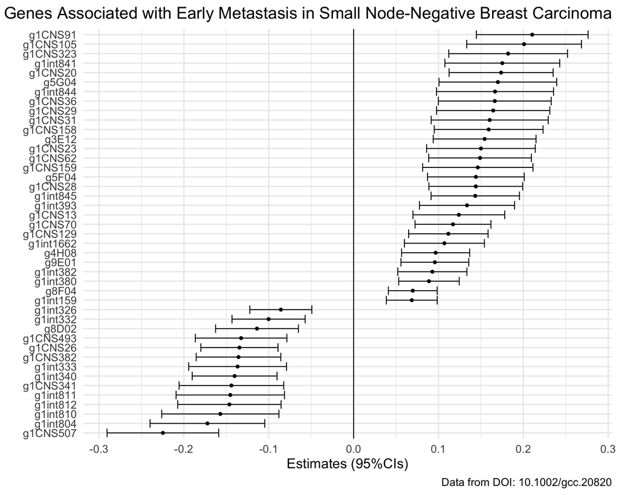

## Volcano Plot GROUP ASSIGNMENT part II

```r
library("ggrepel")
pl <- gravier_estimates |>
  mutate(lbl = case_when(
    is_significant == "yes" ~ gene,
    is_significant == "no" ~ "")) |>
  ggplot(aes(x = estimate,
             y = -log10(p.value),
             colour = is_significant,
             label = lbl)) +
  geom_point(size = 1,
             alpha = 0.5) +
  geom_text_repel(size = 4,
                  max.overlaps = 20) +
  geom_hline(yintercept = 0) +
  theme_minimal(base_size = 16) +
  theme(
    plot.title = element_text(hjust = 1),
    plot.subtitle = element_text(hjust = 1),
    legend.position = "none") +
  labs(
    x = "Estimates",
    y = "-log10(p)",
    title = "Genes Associated with Early Metastasis in Small Node-Negative Breast Carcinoma",
    subtitle = "Genes highlighted in turquoise were significant after multiple testing correction",
    caption = "Data from DOI: 10.1002/gcc.20820")
```

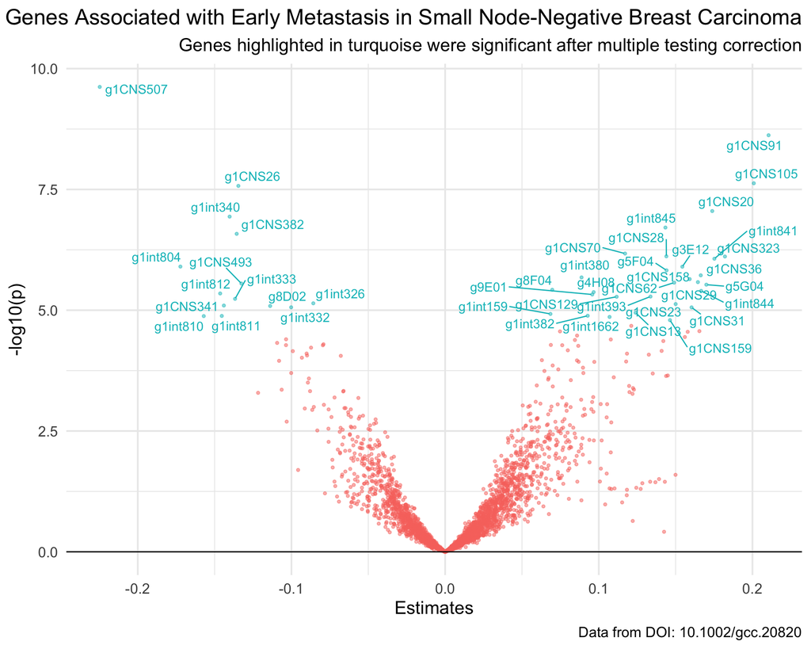

## Disclaimer

This comment was added to several hand ins this time:

- *Overall a nice report, please adjust to the feedback above for the next assignment and also, I am guessing that some issues here were solved with chatGPT or similar, if you do so, it is your responsibility to be able account 100% for the code, that is produced - Please understand that you will “own” any mistakes or design/creative choices taken when completing the code made by the AI, so make sure to understand what is going on!*

In other words: At the final project - Any mistakes made by AI are YOUR mistakes 🫵